# QTM 151 Final Project

Group Members:

1. Shaochen Tu (Class 2348-Section 1)
2. Alison Thieberg
3. Aila Sheri

```python
import pandas as pd
import matplotlib.pyplot as plt
```

#### Introduction:

Formula 1, often referred to as F1, is the premier international auto racing series featuring single-seater cars. With races held in various countries across the globe, it garners immense attention and boasts a diverse pool of drivers. In this analysis, we aim to explore the origins of Formula 1 drivers, focusing on two key questions: which country produces the most drivers, and which country produces the best drivers. Understanding the demographics of Formula 1 drivers is not only intriguing from a statistical standpoint but also sheds light on the global landscape of motorsport talent. By delving into the dataset encompassing driver information, including nationality and performance metrics, we aim to uncover patterns and trends that illuminate the dynamics of driver representation across different countries.

First, we examine the distribution of drivers by nationality to identify which countries contribute the highest number of racers. Subsequently, we narrow our focus to ascertain which country produces the best drivers, defined by those who have secured the top qualifying position in races. Through visualizations and quantitative analysis, we seek to provide insights into the geographical diversity and excellence within the Formula 1 driver community. The analysis unfolds in two main sections: one dedicated to exploring the abundance of drivers from various countries, and the other delving into the prowess of drivers based on their qualifying performances. Through this investigation, we aim to offer a comprehensive overview of the global footprint and competitive landscape of Formula 1 drivers.

#### Datasets:

For this analysis, we will be using 3 datasets of F1 statistics. The constructors dataset gives information about the F1 teams. This includes important information like the team name, country of origin, and wikipedia link. The second dataset we will use is the drivers dataset. This is a large dataset with rows for all F1 drivers. It includes their names and dates of birth, but crutially for us, includes their nationality. The final dataset we will use in the qualifying dataset. This gives us more information on how a specific driver performs.

```python
constructors = pd.read_csv("data_raw/constructors.csv")
drivers = pd.read_csv("data_raw/drivers.csv")
qualifying = pd.read_csv("data_raw/qualifying.csv")
```

#### Merging for a 'most drivers' table:

We want to first discover which country produces the most drivers. We want to explore the datasets and generate a new table that includes all unique drivers and their countries of origin. We first merged the qualifying table with the drivers table, and then that new table with the constructors dataset.

```python
merge = pd.merge(qualifying[['driverId','constructorId','position']],
                    drivers[['driverId','driverRef','dob','nationality']],
                    on = "driverId",
                    how = "left")

merge2 = pd.merge(merge,
                    constructors[['constructorId','name']],
                    on = "constructorId",
                    how = "left")
```

#### Cleaning for a 'most drivers' table:

When we were merging above, we made sure to only include columns that were relevent to the new dataset we were trying to create. Since there were multiple entries for multiple drivers, we had to filter out our dataset and drop any duplicates which we do below.

#### Columns for 'most drivers' table:

Our resultant data set includes an index, driver ID, driver referenace name, date of birth, and nationality. The driver ID and driver reference name are very important for identifying the driver. Drivers can often switch teams, so it is important to follow them only with their driver ID. The nationality is what we are most interested in and will be able to visualize thanks to our merging.

```python
merge3 = merge2.filter(["driverId","driverRef","dob","nationality"], axis=1)

#creates a data frame with one entry for each racer
unique_rows = merge3.drop_duplicates().reset_index()

print(unique_rows)
```

```
     index  driverId        driverRef         dob nationality
0        0         1         hamilton  1985-01-07     British
1        1         9           kubica  1984-12-07      Polish
2        2         5       kovalainen  1981-10-19     Finnish
3        3        13            massa  1981-04-25   Brazilian
4        4         2         heidfeld  1977-05-10      German
..     ...       ...              ...         ...         ...
161   8706       852          tsunoda  2000-05-11    Japanese
162   8712       854  mick_schumacher  1999-03-22      German
163   8713       853          mazepin  1999-03-02     Russian
164   9149       855             zhou  1999-05-30     Chinese
165   9447       856         de_vries  1995-02-06       Dutch

[166 rows x 5 columns]
```

#### Creating a plot for 'most drivers':

We want to count up the drivers for each nationality and create a plot to better display which country has the most drivers in F1. From the chart and the data table we see that Britian and France produce the most F1 drivers.

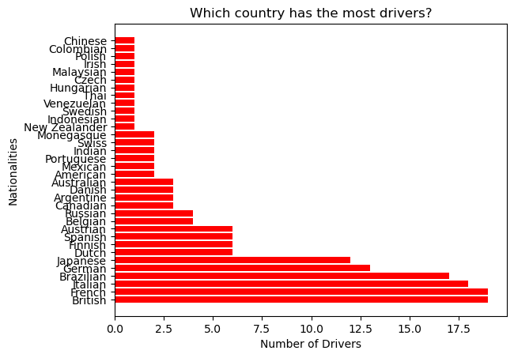

```python
#counts how many racers for each nationality
vec_y = unique_rows["nationality"].value_counts()

#turns the vector into a data frame
for_plot = vec_y.to_frame(name = "count").reset_index()

plt.barh(for_plot["index"],for_plot["count"], color= 'red')
plt.ylabel("Nationalities")
plt.xlabel("Number of Drivers")
plt.title("Which country has the most drivers?")
plt.figure(figsize=(10,50))
```

#### Data cleaning for a 'best drivers' table:

Now that we know what countries produce the most drivers, which country produces the best drivers? We define best as the drivers that have held the 'pole position' or the #1 qualifying spot. This can be found from the qualifying dataset. We use our merge dataset to create a new table based on drivers who have had the #1 position. We then delete the duplicates.

#### Columns for 'best drivers' table:

Our best drivers table includes an index, the driver ID, position, driver reference, date of birth, and nationality. As stated before, the driver ID and referance name are both very important for ensuring there are no duplicate drivers and only one unique observation per driver. The position for all the drivers is 1. It is usful to keep this column in the dataset to ensure that there was no coding errors and all the drivers listed have held that position. Finally, we include nationality. With this we will be able to visualize which country produces the best drivers.

```python
#filters out drivers in the qualifying database that got the first position in races
best_drivers = merge.query("position == 1")

#deleting the column with constructorID
del best_drivers['constructorId']
#removing duplicates
best_drivers_unique = best_drivers.drop_duplicates("driverRef").reset_index()
#counts the amount of times each nationality appears in the data frame
vec_best_con = best_drivers_unique["nationality"].value_counts()

best_con = vec_best_con.to_frame(name = "count").reset_index()

print(best_drivers_unique)
```

```
    index  driverId  position           driverRef         dob nationality
0       0         1         1            hamilton  1985-01-07     British
1      22        13         1               massa  1981-04-25   Brazilian
2      44         9         1              kubica  1984-12-07      Polish
3      66         8         1           raikkonen  1979-10-17     Finnish
4     168         5         1          kovalainen  1981-10-19     Finnish
5     268        20         1              vettel  1987-07-03      German
6     456         4         1              alonso  1981-07-29     Spanish
7     742        30         1  michael_schumacher  1969-01-03      German
8     764        21         1          fisichella  1973-01-14     Italian
9     786        18         1              button  1980-01-19     British
10   1138         2         1            heidfeld  1977-05-10      German
11   1178        15         1              trulli  1974-07-13     Italian
12   1318        31         1             montoya  1975-09-20   Colombian
13   1358        23         1     ralf_schumacher  1975-06-30      German
```

[output cut: 23 more lines]

#### Plot for 'best drivers':

We now want to plot the amount of drivers who have held the pole position per nationality. We can visualize this with a bar chart.

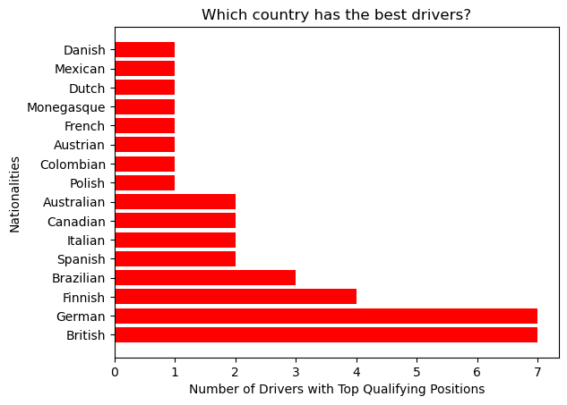

```python
plt.barh(best_con["index"],best_con["count"], color= 'red')
plt.ylabel("Nationalities")
plt.xlabel("Number of Drivers with Top Qualifying Positions")
plt.title("Which country has the best drivers?")
plt.figure(figsize=(10,50))
```